# TVMaze API Vignette

Baldeep Dhada, Dylan Longert, Somya Nagar

2024-02-14

### Load tvmazeWrapper Package

```r
library(tvmazeWrapper)
```

### Using Fuctions

**get_shows():** An API call is made to the TVmaze database with the television show the user inputed as a parameter. The function returns a dataframe of all television shows similar to what the user inputed, as well as all associated data found within the database. NULL is returned if the television show is not found within the database.

**example:**

```r
shows <- get_shows("Game of Thrones")
head(shows, 1)
```

```
#>   id                                             url            name     type
#> 1 82 https://www.tvmaze.com/shows/82/game-of-thrones Game of Thrones Scripted
#>   language                    genres status runtime averageRuntime  premiered
#> 1  English Drama, Adventure, Fantasy  Ended      60             61 2011-04-17
#>        ended                       officialSite schedule.time schedule.days
#> 1 2019-05-19 http://www.hbo.com/game-of-thrones         21:00        Sunday
#>   average weight network.id network.name network.country.name
#> 1     8.9     99          8          HBO        United States
#>   network.country.code network.country.timezone network.officialSite
#> 1                   US         America/New_York https://www.hbo.com/
#>   webChannel.id webChannel.name webChannel.country webChannel.officialSite
#> 1            NA            <NA>                 NA                    <NA>
#>   dvdCountry externals.tvrage externals.thetvdb externals.imdb
#> 1         NA            24493            121361      tt0944947
#>                                                               image.medium
#> 1 https://static.tvmaze.com/uploads/images/medium_portrait/498/1245274.jpg
#>                                                                image.original
#> 1 https://static.tvmaze.com/uploads/images/original_untouched/498/1245274.jpg
#>                                                                                                                                                                                                                                                                                                          …
#> 1 <p>Based on the bestselling book series <i>A Song of Ice and Fire</i> by George R.R. Martin, this sprawling new HBO drama is set in a world where summers span decades and winters can last a lifetime. From the scheming south and the savage eastern lands, to the frozen north and ancient Wall that…
#>      updated                     _links.href
#> 1 1704792924 https://api.tvmaze.com/shows/82
#>                               _links.href
#> 1 https://api.tvmaze.com/episodes/1623968
```

**format_show_name():** This function formats the dataframe returned in the get_shows() function, returning only the television show name, premier date, end date, and genres.

**example:**

```r
format_show_name(shows)
```

```
#>                                  name premiered ended                    genres
#> 1                     Game of Thrones      2011  2019 Drama, Adventure, Fantasy
#> 2 Game of Thrones: Inside the Episode      2019  2019                         ?
#> 3   Hip Hop Tribe 2 : Game of Thrones      2016  2017                     Music
```

**get_seasons():** second API call is made to the TVmaze database with television show id as a parameter. This function returns a dataframe of all available data pertaining to a specific television show.

**example:**

```r
# 82 is the television show id parameter for Game of Thrones
seasons_df <- get_seasons(82)
head(seasons_df, 1)
```

```
#>      id                                                         url number name
#> 1   307 https://www.tvmaze.com/seasons/307/game-of-thrones-season-1      1
#>   episodeOrder premiereDate    endDate network.id network.name
#> 1           10   2011-04-17 2011-06-19          8          HBO
#>   network.country.name network.country.code network.country.timezone
#> 1        United States                   US         America/New_York
#>   network.officialSite webChannel
#> 1 https://www.hbo.com/          ?
#>                                                            image.medium
#> 1 https://static.tvmaze.com/uploads/images/medium_portrait/24/60659.jpg
#>                                                             image.original
#> 1 https://static.tvmaze.com/uploads/images/original_untouched/24/60659.jpg
#>                                                                                                                                                                                                                                                                                                          …
#> 1 <p>Lord Eddard Stark is asked by his old friend, King Robert Baratheon, to serve as the King's Hand following the death of the previous incumbent, Eddard's mentor Jon Arryn. Eddard is reluctant, but receives intelligence suggesting that Jon was murdered. Eddard accepts Robert's offer, planning …
#>                              X_links
#> 1 https://api.tvmaze.com/seasons/307
```

**format_season_name():** This function formats the dataframe returned in the get_seasons() function, returning only season numbers, season names, premier dates, end dates, and number of episodes.

**example:**

```r
# seasons_df is the dataframe with seasons data
seasons <- format_season_name(seasons_df)
head(seasons)
```

```
#>     Season Name Premier  End Episodes
#> 1 Season 1    ?    2011 2011       10
#> 2 Season 2    ?    2012 2012       10
#> 3 Season 3    ?    2013 2013       10
#> 4 Season 4    ?    2014 2014       10
#> 5 Season 5    ?    2015 2015       10
#> 6 Season 6    ?    2016 2016       10
```

**get_episodes_of_season():** A third API call is made to the TVMaze database with season id as a parameter. This function returns a dataframe of all available data pertaining to the season of a television show.

```r
# 307 is the season id for season 1 of Game of Thrones
episodes_df <- get_episodes_of_season(307)
head(episodes_df, 1)
```

```
#>     id
#> 1 4952
#>                                                                          url
#> 1 https://www.tvmaze.com/episodes/4952/game-of-thrones-1x01-winter-is-coming
#>               name season number    type    airdate airtime
#> 1 Winter is Coming      1      1 regular 2011-04-17   21:00
#>                    airstamp runtime average
#> 1 2011-04-18T01:00:00+00:00      60     8.1
#>                                                                image.medium
#> 1 https://static.tvmaze.com/uploads/images/medium_landscape/478/1195111.jpg
#>                                                                image.original
#> 1 https://static.tvmaze.com/uploads/images/original_untouched/478/1195111.jpg
#>                                                                                                                                                                                                                                                                                                          …
#> 1 <p>Lord Eddard Stark, ruler of the North, is summoned to court by his old friend, King Robert Baratheon, to serve as the King's Hand. Eddard reluctantly agrees after learning of a possible threat to the King's life. Eddard's bastard son Jon Snow must make a painful decision about his own future…
#>                            _links.href                     _links.href
#> 1 https://api.tvmaze.com/episodes/4952 https://api.tvmaze.com/shows/82
```

**format_episode_name():** This function formats the dataframe returned in the get_episodes_of_season() function, returning only episode numbers, episode names, and episode ratings.

```r
episodes <- format_episode_name(episodes_df)
head(episodes)
```

```
#>   Episode                                  Name Rating
#> 1    S1E1                      Winter is Coming    8.1
#> 2    S1E2                         The Kingsroad    8.1
#> 3    S1E3                             Lord Snow    7.9
#> 4    S1E4 Cripples, Bastards, and Broken Things    8.1
#> 5    S1E5                 The Wolf and the Lion    8.5
#> 6    S1E6                        A Golden Crown    8.6
```

**get_all_episodes():** A fourth API call is made to the TVMaze database with television show id as a parameter. This function returns a dataframe of all available television show episode data.

```r
# 82 is the television show id parameter for Game of Thrones
all_episodes_df <- get_all_episodes(82)
head(all_episodes_df, 1)
```

```
#>     id
#> 1 4952
#>                                                                          url
#> 1 https://www.tvmaze.com/episodes/4952/game-of-thrones-1x01-winter-is-coming
#>               name season number    type    airdate airtime
#> 1 Winter is Coming      1      1 regular 2011-04-17   21:00
#>                    airstamp runtime average
#> 1 2011-04-18T01:00:00+00:00      60     8.1
#>                                                                image.medium
#> 1 https://static.tvmaze.com/uploads/images/medium_landscape/478/1195111.jpg
#>                                                                image.original
#> 1 https://static.tvmaze.com/uploads/images/original_untouched/478/1195111.jpg
#>                                                                                                                                                                                                                                                                                                          …
#> 1 <p>Lord Eddard Stark, ruler of the North, is summoned to court by his old friend, King Robert Baratheon, to serve as the King's Hand. Eddard reluctantly agrees after learning of a possible threat to the King's life. Eddard's bastard son Jon Snow must make a painful decision about his own future…
#>                            _links.href                     _links.href
#> 1 https://api.tvmaze.com/episodes/4952 https://api.tvmaze.com/shows/82
```

**format_all_episodes():** This function formats the dataframe returned in the get_all_episodes() function, returning only episode numbers, episode names, and episode ratings.

```r
all_episodes <- format_all_episodes(all_episodes_df)
head(all_episodes)
```

```
#>   Episode                                  Name Rating
#> 1    S1E1                      Winter is Coming    8.1
#> 2    S1E2                         The Kingsroad    8.1
#> 3    S1E3                             Lord Snow    7.9
#> 4    S1E4 Cripples, Bastards, and Broken Things    8.1
#> 5    S1E5                 The Wolf and the Lion    8.5
#> 6    S1E6                        A Golden Crown    8.6
```

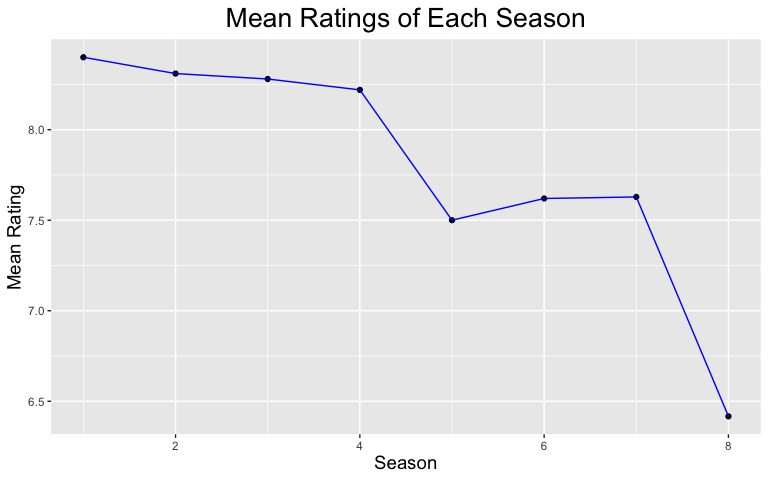

```r
generate_ratings_plot(all_episodes)
```

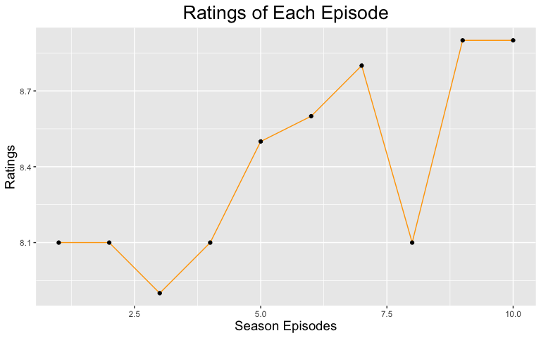

```r
generate_season_ratings_plot(episodes)
```

All of the functionality explained above can be accessed with the `main()` function. It allows the user with an interactive experience to navigate the entire workflow. The usage for that demonstrated below :

**main() :**

```r
main()

Enter a Show (or 0 to exit): Game of thrones

Select a Show Number (or 0 to exit): 1

Select a Season Number (or 0 to exit): 1

1. Plot of average rating per season for all the seasons in a show
2. Plot of ratings for each episodes in a season
Do you want to see any of the 2 visualizations? (or 0 to exit): 1

Enter a Show (or 0 to exit): 0
```